# Cyclistic bike-share analysis(Dec 2020 - Nov 2021)

by Mithran

## **Case study: How Does a Bike-Share Navigate Speedy Success?**

- Period : Dec 2020 to Nov 2021
- Completed on : Jan 2022

## Introduction

This case study serves as the capstone of the [Google Data Analytics Professional Certificate](https://www.coursera.org/professional-certificates/google-data-analytics?utm_source=google&utm_medium=institutions&utm_campaign=gwgsite-gDigital-paidha-sem-bk-data-exa-glp-br-null). Here, I assumed the role of a data analyst working on the marketing team at Cyclistic, a fictional bike-share company in Chicago. The director of marketing believes that the companies future depends upon maximizing the number of annual memberships. My goal was to answer the question: How do casual riders and annual members use Cyclistic bikes differently? I used the data analysis process of Ask, Prepare, Process, Analyze, Share and Act to answer key business questions, as well as I used the tools such as Excel,Tableau,and R programming language. The data has been made available by Motivate International Inc. under this [license](https://ride.divvybikes.com/data-license-agreement)

## Ask phase

The problem I’m trying to solve : How do annual members and casual riders use Cyclistic bikes differently? My insights for this case study : The differences in the variables and their relations, would give key information to describe the difference in user type (member or casual) and it will generate useful information to guide the future marketing program and the above question.

## Prepare phase

I have used Cyclistic’s historical trip data to analyze and identify trends from the website - [divvy-tripdata](https://divvy-tripdata.s3.amazonaws.com/index.html). This data that has been made publicly available has been scrubbed to omit rider’s personal information. * Excel to remove unwanted columns like location data (latitude and longitude), station id and station names as the data are not consistance and create a new column called day_of_week to find the day * Tableau to create a dashboard for an interactive visualization like monthly Usage, week Usage, and percentage of user type * R programming to calculate ride length and Visualization of average ride length by customer type on each month and day of the week

Stakeholders : Director of marketing and Cyclistic executive team

## Process & Analyze phase

### Excel

- Remove unwanted columns such as start_station_name, start_station_id, end_station_name, end_station_id, start_lat, start_lng, end_lat and end_lng
- Aligned and rename the headers for 12 files to the same formate such as ride_id, rideable_type, start_at, end_at, and user_type
- Created a new column called day_of_week to find the day of the week from the start_at column using the function “=TEXT(C2,”dddd”)
- And saved all the files in a CSV format into a new folder called cleaned CSV files

### Tableau

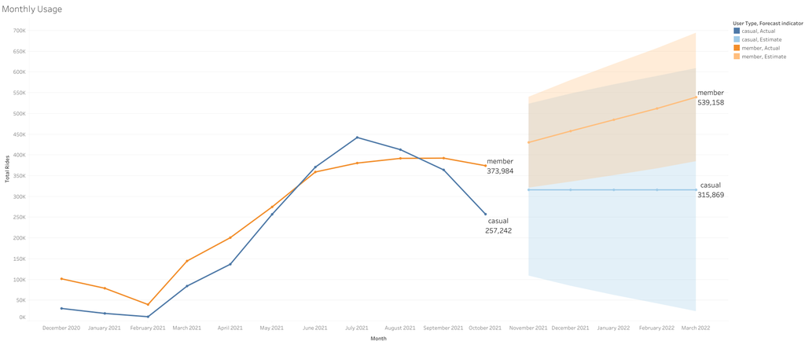

  Please [click here](https://public.tableau.com/app/profile/mithran.seralathan/viz/Casestudyfordec2020toNov2021/CyclisticCasestudy) for a interactive view
- Created a another visualization by user type on each day of the week
- with day_of_week and user_type as a row and column as the count of ride_id
- To differentiate the user type I have included User_type in the color mark

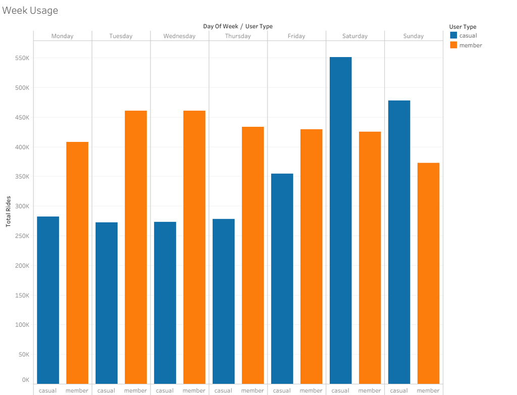

Please [click here](https://public.tableau.com/app/profile/mithran.seralathan/viz/Casestudyfordec2020toNov2021/CyclisticCasestudy) for a interactive view

- Created a dashboard with some other useful visualization like percentage of user type and rideable type Vs. the total ride which is presented below for your reference

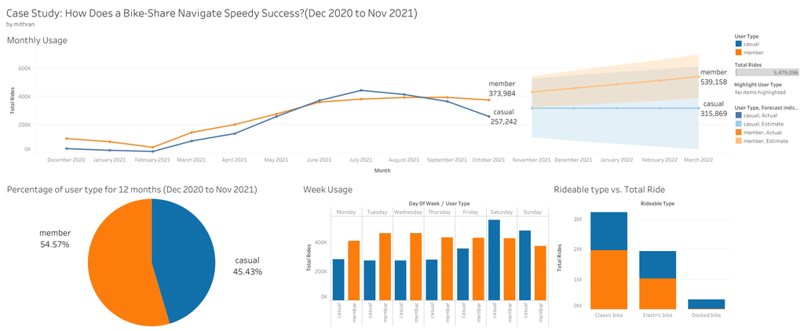

Please [click here](https://public.tableau.com/app/profile/mithran.seralathan/viz/Casestudyfordec2020toNov2021/CyclisticCasestudy) for a interactive view

### R programming

- Installing and reading Packages

```r
install.packages("tidyverse", repos = "http://cran.us.r-project.org",warn.conflicts=F, quietly=T)
install.packages("lubridate", repos = "http://cran.us.r-project.org",warn.conflicts=F, quietly=T)
library(tidyverse)
library(lubridate)
```

```r
library(ggplot2)
library(readr)
```

- Load datasets which is in CSV format

```r
# COLLECT DATA
X2020_12 <- read_csv("~/Case study Cyclistic/Cleaned CSV file/2020_12.csv")
X2021_01 <- read_csv("~/Case study Cyclistic/Cleaned CSV file/2021_01.csv")
X2021_02 <- read_csv("~/Case study Cyclistic/Cleaned CSV file/2021_02.csv")
X2021_03 <- read_csv("~/Case study Cyclistic/Cleaned CSV file/2021_03.csv")
X2021_04 <- read_csv("~/Case study Cyclistic/Cleaned CSV file/2021_04.csv")
X2021_05 <- read_csv("~/Case study Cyclistic/Cleaned CSV file/2021_05.csv")
X2021_06 <- read_csv("~/Case study Cyclistic/Cleaned CSV file/2021_06.csv")
X2021_07 <- read_csv("~/Case study Cyclistic/Cleaned CSV file/2021_07.csv")
X2021_08 <- read_csv("~/Case study Cyclistic/Cleaned CSV file/2021_08.csv")
X2021_09 <- read_csv("~/Case study Cyclistic/Cleaned CSV file/2021_09.csv")
X2021_10 <- read_csv("~/Case study Cyclistic/Cleaned CSV file/2021_10.csv")
X2021_11 <- read_csv("~/Case study Cyclistic/Cleaned CSV file/2021_11.csv")
```

- Combine ino a single data frame

```r
# COMBINE INTO A SINGLE FILE

str(X2020_12)
```

```
## spec_tbl_df [131,573 x 6] (S3: spec_tbl_df/tbl_df/tbl/data.frame)
##  $ ride_id      : chr [1:131573] "70B6A9A437D4C30D" "158A465D4E74C54A" "5262016E0F1F2F9A" "BE119628E44F871E" ...
##  $ rideable_type: chr [1:131573] "classic_bike" "electric_bike" "electric_bike" "electric_bike" ...
##  $ start_at     : chr [1:131573] "27-12-2020 12:44" "18-12-2020 17:37" "15-12-2020 15:04" "15-12-2020 15:54" ...
##  $ end_at       : chr [1:131573] "27-12-2020 12:55" "18-12-2020 17:44" "15-12-2020 15:11" "15-12-2020 16:00" ...
##  $ user_type    : chr [1:131573] "member" "member" "member" "member" ...
##  $ day_of_week  : chr [1:131573] "Sunday" "Friday" "Tuesday" "Tuesday" ...
##  - attr(*, "spec")=
##   .. cols(
##   ..   ride_id = col_character(),
##   ..   rideable_type = col_character(),
##   ..   start_at = col_character(),
##   ..   end_at = col_character(),
##   ..   user_type = col_character(),
##   ..   day_of_week = col_character()
##   .. )
##  - attr(*, "problems")=<externalptr>
```

```r
str(X2021_01)
```

```
## spec_tbl_df [96,834 x 6] (S3: spec_tbl_df/tbl_df/tbl/data.frame)
##  $ ride_id      : chr [1:96834] "E19E6F1B8D4C42ED" "DC88F20C2C55F27F" "EC45C94683FE3F27" "4FA453A75AE377DB" ...
##  $ rideable_type: chr [1:96834] "electric_bike" "electric_bike" "electric_bike" "electric_bike" ...
##  $ start_at     : chr [1:96834] "23-01-2021 16:14" "27-01-2021 18:43" "21-01-2021 22:35" "07-01-2021 13:31" ...
##  $ end_at       : chr [1:96834] "23-01-2021 16:24" "27-01-2021 18:47" "21-01-2021 22:37" "07-01-2021 13:42" ...
##  $ user_type    : chr [1:96834] "member" "member" "member" "member" ...
##  $ day_of_week  : chr [1:96834] "Saturday" "Wednesday" "Thursday" "Thursday" ...
##  - attr(*, "spec")=
##   .. cols(
##   ..   ride_id = col_character(),
##   ..   rideable_type = col_character(),
##   ..   start_at = col_character(),
##   ..   end_at = col_character(),
##   ..   user_type = col_character(),
##   ..   day_of_week = col_character()
##   .. )
##  - attr(*, "problems")=<externalptr>
```

```r
str(X2021_02)
```

```
## spec_tbl_df [49,622 x 6] (S3: spec_tbl_df/tbl_df/tbl/data.frame)
##  $ ride_id      : chr [1:49622] "89E7AA6C29227EFF" "0FEFDE2603568365" "E6159D746B2DBB91" "B32D3199F1C2E75B" ...
##  $ rideable_type: chr [1:49622] "classic_bike" "classic_bike" "electric_bike" "classic_bike" ...
##  $ start_at     : chr [1:49622] "12-02-2021 16:14" "14-02-2021 17:52" "09-02-2021 19:10" "02-02-2021 17:49" ...
##  $ end_at       : chr [1:49622] "12-02-2021 16:21" "14-02-2021 18:12" "09-02-2021 19:19" "02-02-2021 17:54" ...
##  $ user_type    : chr [1:49622] "member" "casual" "member" "member" ...
##  $ day_of_week  : chr [1:49622] "Friday" "Sunday" "Tuesday" "Tuesday" ...
##  - attr(*, "spec")=
##   .. cols(
##   ..   ride_id = col_character(),
##   ..   rideable_type = col_character(),
##   ..   start_at = col_character(),
##   ..   end_at = col_character(),
##   ..   user_type = col_character(),
##   ..   day_of_week = col_character()
##   .. )
##  - attr(*, "problems")=<externalptr>
```

```r
str(X2021_03)
```

```
## spec_tbl_df [228,496 x 6] (S3: spec_tbl_df/tbl_df/tbl/data.frame)
##  $ ride_id      : chr [1:228496] "CFA86D4455AA1030" "30D9DC61227D1AF3" "846D87A15682A284" "994D05AA75A168F2" ...
##  $ rideable_type: chr [1:228496] "classic_bike" "classic_bike" "classic_bike" "classic_bike" ...
##  $ start_at     : chr [1:228496] "16-03-2021 08:32" "28-03-2021 01:26" "11-03-2021 21:17" "11-03-2021 13:26" ...
##  $ end_at       : chr [1:228496] "16-03-2021 08:36" "28-03-2021 01:36" "11-03-2021 21:33" "11-03-2021 13:55" ...
##  $ user_type    : chr [1:228496] "casual" "casual" "casual" "casual" ...
##  $ day_of_week  : chr [1:228496] "Tuesday" "Sunday" "Thursday" "Thursday" ...
##  - attr(*, "spec")=
##   .. cols(
##   ..   ride_id = col_character(),
##   ..   rideable_type = col_character(),
##   ..   start_at = col_character(),
##   ..   end_at = col_character(),
##   ..   user_type = col_character(),
##   ..   day_of_week = col_character()
##   .. )
##  - attr(*, "problems")=<externalptr>
```

```r
str(X2021_04)
```

```
## spec_tbl_df [337,230 x 6] (S3: spec_tbl_df/tbl_df/tbl/data.frame)
##  $ ride_id      : chr [1:337230] "6C992BD37A98A63F" "1E0145613A209000" "E498E15508A80BAD" "1887262AD101C604" ...
##  $ rideable_type: chr [1:337230] "classic_bike" "docked_bike" "docked_bike" "classic_bike" ...
##  $ start_at     : chr [1:337230] "12-04-2021 18:25" "27-04-2021 17:27" "03-04-2021 12:42" "17-04-2021 09:17" ...
##  $ end_at       : chr [1:337230] "12-04-2021 18:56" "27-04-2021 18:31" "07-04-2021 11:40" "17-04-2021 09:42" ...
##  $ user_type    : chr [1:337230] "member" "casual" "casual" "member" ...
##  $ day_of_week  : chr [1:337230] "Monday" "Tuesday" "Saturday" "Saturday" ...
##  - attr(*, "spec")=
##   .. cols(
##   ..   ride_id = col_character(),
##   ..   rideable_type = col_character(),
##   ..   start_at = col_character(),
##   ..   end_at = col_character(),
##   ..   user_type = col_character(),
##   ..   day_of_week = col_character()
##   .. )
##  - attr(*, "problems")=<externalptr>
```

```r
str(X2021_05)
```

```
## spec_tbl_df [531,633 x 6] (S3: spec_tbl_df/tbl_df/tbl/data.frame)
##  $ ride_id      : chr [1:531633] "C809ED75D6160B2A" "DD59FDCE0ACACAF3" "0AB83CB88C43EFC2" "7881AC6D39110C60" ...
##  $ rideable_type: chr [1:531633] "electric_bike" "electric_bike" "electric_bike" "electric_bike" ...
##  $ start_at     : chr [1:531633] "30-05-2021 11:58" "30-05-2021 11:29" "30-05-2021 14:24" "30-05-2021 14:25" ...
##  $ end_at       : chr [1:531633] "30-05-2021 12:10" "30-05-2021 12:14" "30-05-2021 14:25" "30-05-2021 14:41" ...
##  $ user_type    : chr [1:531633] "casual" "casual" "casual" "casual" ...
##  $ day_of_week  : chr [1:531633] "Sunday" "Sunday" "Sunday" "Sunday" ...
##  - attr(*, "spec")=
##   .. cols(
##   ..   ride_id = col_character(),
##   ..   rideable_type = col_character(),
##   ..   start_at = col_character(),
##   ..   end_at = col_character(),
##   ..   user_type = col_character(),
##   ..   day_of_week = col_character()
##   .. )
##  - attr(*, "problems")=<externalptr>
```

```r
str(X2021_06)
```

```
## spec_tbl_df [729,595 x 6] (S3: spec_tbl_df/tbl_df/tbl/data.frame)
##  $ ride_id      : chr [1:729595] "99FEC93BA843FB20" "06048DCFC8520CAF" "9598066F68045DF2" "B03C0FE48C412214" ...
##  $ rideable_type: chr [1:729595] "electric_bike" "electric_bike" "electric_bike" "electric_bike" ...
##  $ start_at     : chr [1:729595] "13-06-2021 14:31" "04-06-2021 11:18" "04-06-2021 09:49" "03-06-2021 19:56" ...
##  $ end_at       : chr [1:729595] "13-06-2021 14:34" "04-06-2021 11:24" "04-06-2021 09:55" "03-06-2021 20:21" ...
##  $ user_type    : chr [1:729595] "member" "member" "member" "member" ...
##  $ day_of_week  : chr [1:729595] "Sunday" "Friday" "Friday" "Thursday" ...
##  - attr(*, "spec")=
##   .. cols(
##   ..   ride_id = col_character(),
##   ..   rideable_type = col_character(),
##   ..   start_at = col_character(),
##   ..   end_at = col_character(),
##   ..   user_type = col_character(),
##   ..   day_of_week = col_character()
##   .. )
##  - attr(*, "problems")=<externalptr>
```

```r
str(X2021_07)
```

```
## spec_tbl_df [822,410 x 6] (S3: spec_tbl_df/tbl_df/tbl/data.frame)
##  $ ride_id      : chr [1:822410] "0A1B623926EF4E16" "B2D5583A5A5E76EE" "6F264597DDBF427A" "379B58EAB20E8AA5" ...
##  $ rideable_type: chr [1:822410] "docked_bike" "classic_bike" "classic_bike" "classic_bike" ...
##  $ start_at     : chr [1:822410] "02-07-2021 14:44" "07-07-2021 16:57" "25-07-2021 11:30" "08-07-2021 22:08" ...
##  $ end_at       : chr [1:822410] "02-07-2021 15:19" "07-07-2021 17:16" "25-07-2021 11:48" "08-07-2021 22:23" ...
##  $ user_type    : chr [1:822410] "casual" "casual" "member" "member" ...
##  $ day_of_week  : chr [1:822410] "Friday" "Wednesday" "Sunday" "Thursday" ...
##  - attr(*, "spec")=
##   .. cols(
##   ..   ride_id = col_character(),
##   ..   rideable_type = col_character(),
##   ..   start_at = col_character(),
##   ..   end_at = col_character(),
##   ..   user_type = col_character(),
##   ..   day_of_week = col_character()
##   .. )
##  - attr(*, "problems")=<externalptr>
```

```r
str(X2021_08)
```

```
## spec_tbl_df [804,352 x 6] (S3: spec_tbl_df/tbl_df/tbl/data.frame)
##  $ ride_id      : chr [1:804352] "99103BB87CC6C1BB" "EAFCCCFB0A3FC5A1" "9EF4F46C57AD234D" "5834D3208BFAF1DA" ...
##  $ rideable_type: chr [1:804352] "electric_bike" "electric_bike" "electric_bike" "electric_bike" ...
##  $ start_at     : chr [1:804352] "10-08-2021 17:15" "10-08-2021 17:23" "21-08-2021 02:34" "21-08-2021 06:52" ...
##  $ end_at       : chr [1:804352] "10-08-2021 17:22" "10-08-2021 17:39" "21-08-2021 02:50" "21-08-2021 07:08" ...
##  $ user_type    : chr [1:804352] "member" "member" "member" "member" ...
##  $ day_of_week  : chr [1:804352] "Tuesday" "Tuesday" "Saturday" "Saturday" ...
##  - attr(*, "spec")=
##   .. cols(
##   ..   ride_id = col_character(),
##   ..   rideable_type = col_character(),
##   ..   start_at = col_character(),
##   ..   end_at = col_character(),
##   ..   user_type = col_character(),
##   ..   day_of_week = col_character()
##   .. )
##  - attr(*, "problems")=<externalptr>
```

```r
str(X2021_09)
```

```
## spec_tbl_df [756,147 x 6] (S3: spec_tbl_df/tbl_df/tbl/data.frame)
##  $ ride_id      : chr [1:756147] "9DC7B962304CBFD8" "F930E2C6872D6B32" "6EF72137900BB910" "78D1DE133B3DBF55" ...
##  $ rideable_type: chr [1:756147] "electric_bike" "electric_bike" "electric_bike" "electric_bike" ...
##  $ start_at     : chr [1:756147] "28-09-2021 16:07" "28-09-2021 14:24" "28-09-2021 00:20" "28-09-2021 14:51" ...
##  $ end_at       : chr [1:756147] "28-09-2021 16:09" "28-09-2021 14:40" "28-09-2021 00:23" "28-09-2021 15:00" ...
##  $ user_type    : chr [1:756147] "casual" "casual" "casual" "casual" ...
##  $ day_of_week  : chr [1:756147] "Tuesday" "Tuesday" "Tuesday" "Tuesday" ...
##  - attr(*, "spec")=
##   .. cols(
##   ..   ride_id = col_character(),
##   ..   rideable_type = col_character(),
##   ..   start_at = col_character(),
##   ..   end_at = col_character(),
##   ..   user_type = col_character(),
##   ..   day_of_week = col_character()
##   .. )
##  - attr(*, "problems")=<externalptr>
```

```r
str(X2021_10)
```

```
## spec_tbl_df [631,226 x 6] (S3: spec_tbl_df/tbl_df/tbl/data.frame)
##  $ ride_id      : chr [1:631226] "620BC6107255BF4C" "4471C70731AB2E45" "26CA69D43D15EE14" "362947F0437E1514" ...
##  $ rideable_type: chr [1:631226] "electric_bike" "electric_bike" "electric_bike" "electric_bike" ...
##  $ start_at     : chr [1:631226] "22-10-2021 12:46" "21-10-2021 09:12" "16-10-2021 16:28" "16-10-2021 16:17" ...
##  $ end_at       : chr [1:631226] "22-10-2021 12:49" "21-10-2021 09:14" "16-10-2021 16:36" "16-10-2021 16:19" ...
##  $ user_type    : chr [1:631226] "member" "member" "member" "member" ...
##  $ day_of_week  : chr [1:631226] "Friday" "Thursday" "Saturday" "Saturday" ...
##  - attr(*, "spec")=
##   .. cols(
##   ..   ride_id = col_character(),
##   ..   rideable_type = col_character(),
##   ..   start_at = col_character(),
##   ..   end_at = col_character(),
##   ..   user_type = col_character(),
##   ..   day_of_week = col_character()
##   .. )
##  - attr(*, "problems")=<externalptr>
```

```r
str(X2021_11)
```

```
## spec_tbl_df [359,978 x 6] (S3: spec_tbl_df/tbl_df/tbl/data.frame)
##  $ ride_id      : chr [1:359978] "7C00A93E10556E47" "90854840DFD508BA" "0A7D10CDD144061C" "2F3BE33085BCFF02" ...
##  $ rideable_type: chr [1:359978] "electric_bike" "electric_bike" "electric_bike" "electric_bike" ...
##  $ start_at     : chr [1:359978] "27-11-2021 13:27" "27-11-2021 13:38" "26-11-2021 22:03" "27-11-2021 09:56" ...
##  $ end_at       : chr [1:359978] "27-11-2021 13:46" "27-11-2021 13:56" "26-11-2021 22:05" "27-11-2021 10:01" ...
##  $ user_type    : chr [1:359978] "casual" "casual" "casual" "casual" ...
##  $ day_of_week  : chr [1:359978] "Saturday" "Saturday" "Friday" "Saturday" ...
##  - attr(*, "spec")=
##   .. cols(
##   ..   ride_id = col_character(),
##   ..   rideable_type = col_character(),
##   ..   start_at = col_character(),
##   ..   end_at = col_character(),
##   ..   user_type = col_character(),
##   ..   day_of_week = col_character()
##   .. )
##  - attr(*, "problems")=<externalptr>
```

```r
all_trips <- bind_rows(X2020_12, X2021_01, X2021_02, X2021_03, X2021_04, X2021_05, X2021_06, X2021_07, X2021_08,
                       X2021_09, X2021_10, X2021_11)
View(all_trips)
```

- Changing date format

```r
#Formating the date for R programming to read
all_trips$start_at= strptime(all_trips$start_at,format='%d-%m-%Y %H:%M')
all_trips$end_at= strptime(all_trips$end_at,format='%d-%m-%Y %H:%M')
head(all_trips)
```

```
## # A tibble: 6 x 6
##   ride_id        rideable_type start_at            end_at              user_type
##   <chr>          <chr>         <dttm>              <dttm>              <chr>
## 1 70B6A9A437D4C~ classic_bike  2020-12-27 12:44:00 2020-12-27 12:55:00 member
## 2 158A465D4E74C~ electric_bike 2020-12-18 17:37:00 2020-12-18 17:44:00 member
## 3 5262016E0F1F2~ electric_bike 2020-12-15 15:04:00 2020-12-15 15:11:00 member
## 4 BE119628E44F8~ electric_bike 2020-12-15 15:54:00 2020-12-15 16:00:00 member
## 5 69AF78D57854E~ electric_bike 2020-12-22 12:08:00 2020-12-22 12:10:00 member
## 6 C1DECC4AB4888~ electric_bike 2020-12-22 13:26:00 2020-12-22 13:34:00 member
## # ... with 1 more variable: day_of_week <chr>
```

- Calculating ride length

```r
#Finding ride length
all_trips$ride_length <- difftime(all_trips$end_at,all_trips$start_at)
#convert the seconds to minutes
all_trips$ride_length <- as.numeric(as.character(all_trips$ride_length))/60
head(all_trips)
```

```
## # A tibble: 6 x 7
##   ride_id        rideable_type start_at            end_at              user_type
##   <chr>          <chr>         <dttm>              <dttm>              <chr>
## 1 70B6A9A437D4C~ classic_bike  2020-12-27 12:44:00 2020-12-27 12:55:00 member
## 2 158A465D4E74C~ electric_bike 2020-12-18 17:37:00 2020-12-18 17:44:00 member
## 3 5262016E0F1F2~ electric_bike 2020-12-15 15:04:00 2020-12-15 15:11:00 member
## 4 BE119628E44F8~ electric_bike 2020-12-15 15:54:00 2020-12-15 16:00:00 member
## 5 69AF78D57854E~ electric_bike 2020-12-22 12:08:00 2020-12-22 12:10:00 member
## 6 C1DECC4AB4888~ electric_bike 2020-12-22 13:26:00 2020-12-22 13:34:00 member
## # ... with 2 more variables: day_of_week <chr>, ride_length <dbl>
```

- order by day of week and month

```r
  #order by day of week
all_trips$day_of_week <-
  ordered(all_trips$day_of_week, levels=c("Monday", "Tuesday", "Wednesday", "Thursday",
                                                 "Friday", "Saturday", "Sunday"))
  #Create a new column for month
all_trips$month <- format(as.Date(all_trips$start_at),'%b-%y')

  #order by day of month
all_trips$month <-
  ordered(all_trips$month, levels=c("Dec-20", "Jan-21", "Feb-21", "Mar-21",
                                           "Apr-21", "May-21","Jun-21","Jul-21",
                                           "Aug-21", "Sep-21", "Oct-21","Nov-21"))
head(all_trips)
```

```
## # A tibble: 6 x 8
##   ride_id        rideable_type start_at            end_at              user_type
##   <chr>          <chr>         <dttm>              <dttm>              <chr>
## 1 70B6A9A437D4C~ classic_bike  2020-12-27 12:44:00 2020-12-27 12:55:00 member
## 2 158A465D4E74C~ electric_bike 2020-12-18 17:37:00 2020-12-18 17:44:00 member
## 3 5262016E0F1F2~ electric_bike 2020-12-15 15:04:00 2020-12-15 15:11:00 member
## 4 BE119628E44F8~ electric_bike 2020-12-15 15:54:00 2020-12-15 16:00:00 member
## 5 69AF78D57854E~ electric_bike 2020-12-22 12:08:00 2020-12-22 12:10:00 member
## 6 C1DECC4AB4888~ electric_bike 2020-12-22 13:26:00 2020-12-22 13:34:00 member
## # ... with 3 more variables: day_of_week <ord>, ride_length <dbl>, month <ord>
```

- Eliminating negative value from ride length

```r
# remove negative from ride length
all_trips <- all_trips[all_trips$ride_length >= 0,]
```

## Share Phase

- Statistical summary of trip_duration by customer_type

```r
# statictical summary of trip_duration for all trips
summary(all_trips$ride_length)
```

```
##     Min.  1st Qu.   Median     Mean  3rd Qu.     Max.
##     0.00     7.00    12.00    22.13    22.00 55944.00
```

```r
all_trips %>%
  group_by(user_type) %>%
  summarise(min_ride_length = min(ride_length),max_trip_duration = max(ride_length),
            median_trip_duration = median(ride_length), mean_trip_duration = mean(ride_length))
```

```
## # A tibble: 2 x 5
##   user_type min_ride_length max_trip_duration median_trip_dura~ mean_trip_durat~
##   <chr>               <dbl>             <dbl>             <dbl>            <dbl>
## 1 casual                  0             55944                16             32.2
## 2 member                  0              1560                10             13.8
```

- Average number of trips by customer type and month

```r
unique(all_trips$month)
```

```
##  [1] Dec-20 Jan-21 Feb-21 Mar-21 Apr-21 May-21 Jun-21 Jul-21 Aug-21 Sep-21
## [11] Oct-21 Nov-21
## 12 Levels: Dec-20 < Jan-21 < Feb-21 < Mar-21 < Apr-21 < May-21 < ... < Nov-21
```

```r
all_trips %>%
  group_by(user_type, month) %>%
  summarise(number_of_rides = n(),average_duration_mins = mean(ride_length))
```

```
## # A tibble: 24 x 4
## # Groups:   user_type [2]
##    user_type month  number_of_rides average_duration_mins
##    <chr>     <ord>            <int>                 <dbl>
##  1 casual    Dec-20           30000                  26.8
##  2 casual    Jan-21           18117                  25.7
##  3 casual    Feb-21           10131                  49.4
##  4 casual    Mar-21           84033                  38.2
##  5 casual    Apr-21          136601                  38.0
##  6 casual    May-21          256916                  38.2
##  7 casual    Jun-21          370680                  37.1
##  8 casual    Jul-21          442056                  32.8
##  9 casual    Aug-21          412666                  28.8
## 10 casual    Sep-21          363888                  27.8
## # ... with 14 more rows
```

- Visualization of average ride length by customer type on each day of week

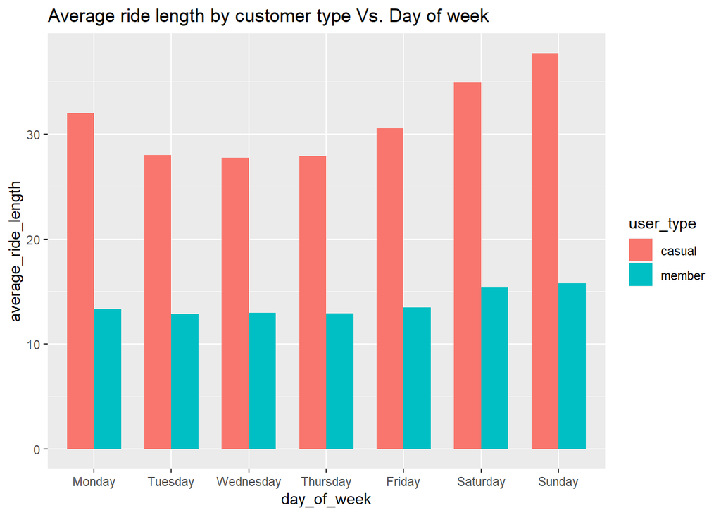

```r
all_trips %>%
  group_by(user_type, day_of_week) %>%
  summarise(average_ride_length = mean(ride_length)) %>%
  ggplot(aes(x = day_of_week, y = average_ride_length, fill = user_type)) +
  geom_col(width=0.7, position = position_dodge(width=0.7)) +
  labs(title ="Average ride length by customer type Vs. Day of week")
```

- Visualization of average ride length by customer type on each month

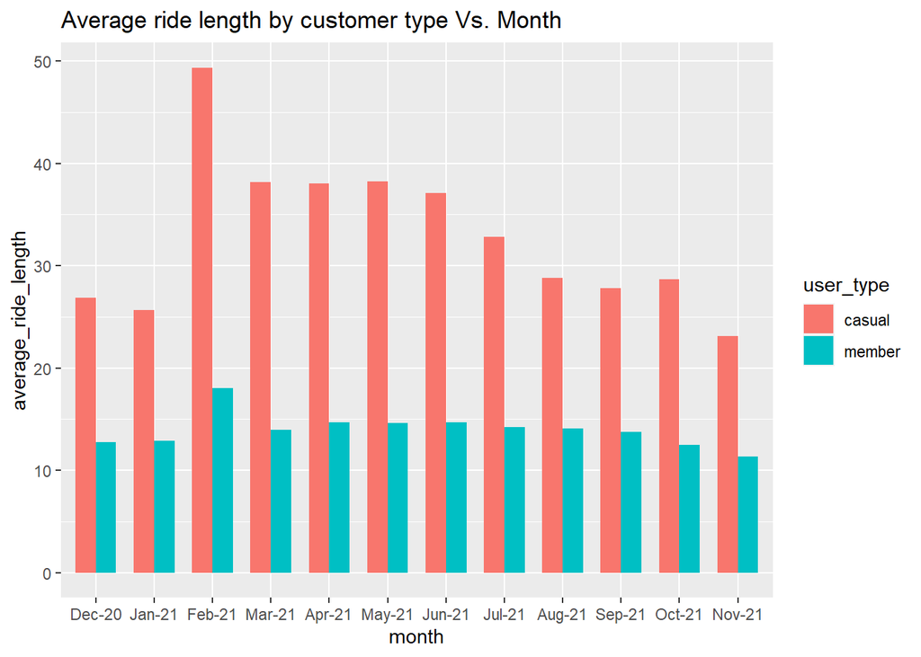

```r
all_trips %>%
  group_by(user_type, month) %>%
  summarise(average_ride_length = mean(ride_length)) %>%
  ggplot(aes(x = month, y = average_ride_length, fill = user_type)) +
  geom_col(width=0.7, position = position_dodge(width=0.7)) +
  labs(title ="Average ride length by customer type Vs. Month")
```

## Resources

[Kaggle community](https://www.kaggle.com/)

[Stack Overflow](https://stackoverflow.com/)

[Lots of Google](http://https://www.google.co.in/?gws_rd=ssl)

[Google Data Analytics Professional Certificate](https://www.coursera.org/professional-certificates/google-data-analytics)